# Predictive Claims Reservation and Risk Assessment for Insurance

## Business Use Case

**Predictive Claims Reserving and Risk Assessment for Insurance**

**Purpose:**  
To automate, standardize, and enhance the accuracy of Workers' Compensation (WC) claims reserving and risk assessment using advanced data science and machine learning techniques.

> **⚠️ Critical Pain Point**: Current model development cycles take **7-12 months** from data extraction to final production models, with manual iterations creating bottlenecks in rate filings and risk decisions. This analysis demonstrates both the scale of the challenge and the path to modernization.

## Key Business Objectives

**Accurate Reserving:**  
Predict the required reserves for open WC claims at various maturity points (e.g., day 0, 30, 60, etc.) to ensure financial stability and regulatory compliance.

**Early Risk Identification:**  
Flag high-risk or exceptional claims early using predictive models, enabling proactive claims management and intervention.

**Operational Efficiency:**  
Replace manual, spreadsheet-based, or legacy SAS processes with a scalable, automated, and auditable MLOps platform (leveraging modern data lakehouse architecture, Python, R, and AKUR8).

**Regulatory and Reporting Compliance:**  
Ensure all reserving calculations and business rules are transparent, reproducible, and easily auditable for internal and external stakeholders.

**Integration with Pricing:**  
Incorporate actuarial pricing models (e.g., from AKUR8) into the claims workflow for holistic risk and profitability management.

## Feature Engineering: Business Context and Value

**Feature Engineering: Business Context and Value**

Feature engineering is the process of creating new variables ("features") from raw data to improve the predictive power and interpretability of data science and machine learning models. In insurance, some features are static—such as policyholder age, claim type, or state—and are explicitly requested and extracted during data wrangling. However, the true value of feature engineering lies in deriving new, informative features through a scientific, iterative process. This includes combining, transforming, or aggregating existing data to capture complex patterns (e.g., injury clusters, maturity bands, risk scores, or NLP-derived sentiment from claim notes). Effective feature engineering not only facilitates robust feature selection for modeling but also enables the development of custom, business-specific insights that drive more accurate underwriting, reserving, and risk assessment.

These features—both static and engineered—are identified and mapped in the conceptual data model during the planning phase, ensuring that all critical data elements for insurance analytics are architected up front and available for robust feature selection and modeling.

## Typical Users

- Actuarial teams (for reserving and pricing)
- Claims management and operations
- Finance and risk officers
- Data science and analytics teams

## Summary Statement

This pipeline enables insurance carriers to automate and optimize the reserving process for workers' compensation claims, leveraging modern data science and machine learning to improve reserve accuracy, identify risks early, and streamline regulatory reporting.

## Current State

**Executive Summary: Predictive Claims Reserving & Risk Assessment for Insurance**

**Business Use Case:**  
Automate, standardize, and enhance the accuracy of Workers' Compensation (WC) claims reserving and risk assessment. The goal is to deliver:

- Accurate, explainable reserves at multiple claim maturity points.
- Early risk identification for proactive claims management.
- Operational efficiency by replacing manual, SAS-based processes with scalable, auditable pipelines.
- Regulatory compliance and transparent reporting.
- Integration with actuarial pricing (e.g., AKUR8).

**Current State: Custom, Data-Driven Actuarial Data Science**

- Highly manual, custom model development: Actuarial and analytics teams use SAS for data wrangling, RStudio/Jupyter for feature engineering and modeling, and AKUR8 for insurance pricing and regulatory models.
- Batch scoring: Models (including AKUR8, Random Forest, XGBoost, ensembles) are trained and scored in batch, often running for days.
- Ad-hoc, notebook-driven workflows: Teams stitch together SAS, R, Python, and notebooks for data prep, feature engineering, training, and scoring.
- Limited automation and metadata management: Experiment tracking, feature reuse, and model registry are mostly manual or siloed.
- Pain points: Heavy IT dependency, lack of self-service, poor versioning, and fragmented data/metadata.

## Inventory Findings

**Asset Analysis Summary** (N=506 total assets)

These findings establish the baseline for modernization priorities and demonstrate the scale of manual processes requiring automation and governance improvements.

## 1) Key Pain Points & Modernization Drivers

**Process Inefficiencies:**

- Fragmented tooling across SAS, R, Python, and AKUR8 creates manual handoffs and increases error potential.
- Model development cycles extend 7-12 months from initial data extraction to production deployment.
- Manual iterations for feature engineering, algorithm selection, and model refinement consume significant actuarial resources.

**Governance & Compliance Risks:**

- 122 assets with unknown execution cadence expose the organization to audit and regulatory compliance challenges.
- Limited experiment tracking and version control result in irreproducible results and lost institutional knowledge.
- Lack of automated lineage documentation complicates regulatory reporting and internal audit requirements.

**Scalability Constraints:**

- Batch processing of large claims triangles requires data sampling, limiting model accuracy and statistical confidence.
- AKUR8 model training cycles of 3-4 days per model create bottlenecks in actuarial pricing updates.
- Stochastic simulation requirements exceed current infrastructure capacity for comprehensive risk assessment.

**Operational Gaps:**

- No centralized feature store leads to redundant engineering efforts across teams.
- Absence of automated retraining pipelines requires manual intervention when model drift is detected.
- Distributed model artifacts across file systems and notebooks hinder collaboration and knowledge sharing.

These pain points demonstrate the need for a unified platform approach that preserves actuarial rigor while introducing automation, governance, and scalability improvements.

## 2) Setup & Data

This cell loads required libraries, creates an output directory, and defines the **inventory counts** for:

- Functional Areas
- Complexity Bands (by LOC)
- Scheduling Types (cadence)

```
Functional Areas:
```

[output not shown]

```
Complexity Bands:
```

[output not shown]

```
Scheduling Types:
```

[output not shown]

```
Data loaded. Ready to render charts.
```

```
Total Assets (Functional Areas): 506
Total Assets (Complexity Bands): 506
Total Assets (Scheduling Types): 506
Most Common Functional Area: Analytics (177 assets)
Complexity Distribution: {'Simple (<500 LOC)': '65.0%', 'Medium (501–1000 LOC)': '17.6%', 'Complex (1001–2000 LOC)': '11.5%', 'Very Complex (>2000 LOC)': '5.9%'}
Scheduling Gaps: 122 assets with unknown cadence (metadata gap to address).
✅ Data validation passed: All counts align with N=506.
```

## 3) Assets by Functional Area

### Functional Area Breakdown

Assets span core actuarial functions (Analytics, Modeling, Pricing, Reserving, Statistical Reporting), sourced from current-state artifacts. This highlights distribution imbalances—e.g., Analytics dominates (177 assets)—informing resource allocation and modernization priorities.

**Narrator's Guide**: "This bar chart shows our asset distribution across functional areas. Notice how Analytics leads with 177 assets, followed closely by Reserving at 140. This imbalance suggests we should prioritize Analytics for CI/CD pipelines, as it represents the largest concentration of our portfolio."

Generates a bar chart showing the asset distribution across **Analytics, Modeling, Pricing, Reserving,** and **Statistical Reporting**.  
**What it shows**: Clear visual hierarchy of where our assets are concentrated, with callouts for the top two areas.  
Exports to: `charts/functional_area_bar.png`.

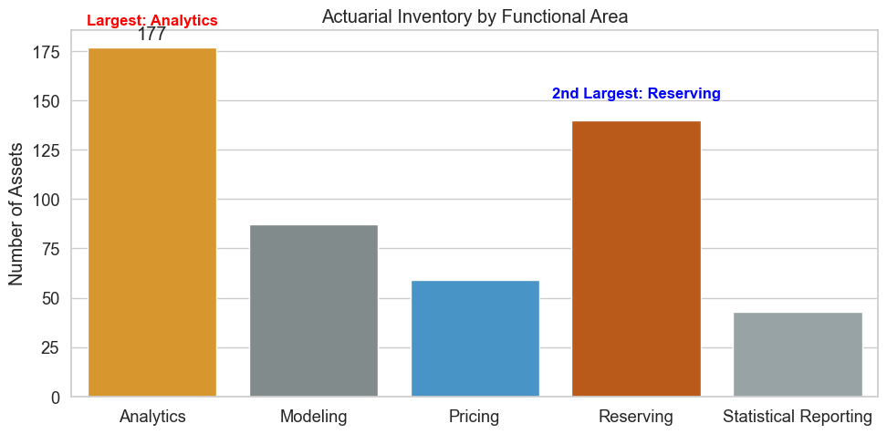

```
Exported: charts\functional_area_bar.png
```

## 4) Actuarial Inventory Overview

This slide provides a snapshot of our actuarial inventory. As you can see, the largest concentration of assets is in Analytics and Reserving, with significant complexity across the portfolio. Scheduling varies from ad hoc to annual, reflecting both operational and regulatory needs. These metrics set the stage for understanding the scale and diversity of our actuarial environment.

### Actuarial Inventory Snapshot

[output not shown]

## 5) Complexity Bands

### Complexity Assessment

Based on Lines of Code (LOC), most assets are simple (<500 LOC), but complex/very complex items (88 assets) signal legacy challenges. Mapping these fully is unsustainable; focus on refactoring high-complexity pipelines for cloud migration.

**Narrator's Guide**: "The stacked bar illustrates complexity by LOC bands. 65% are simple, but 17% are complex or very complex— these are our high-risk legacy assets that need rewriting, not just migration."

Creates a **100% stacked bar** to show the share of assets in each **LOC band**:

- Simple <500
- Medium 501–1000
- Complex 1001–2000
- Very Complex >2000

**What it shows**: Proportional breakdown of complexity, emphasizing the burden of complex assets.  
Exports to: `charts/complexity_bands_stacked_bar.png`.

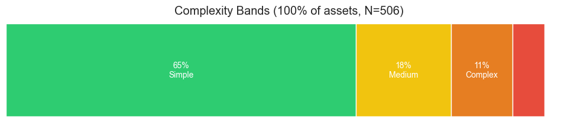

```
Exported: charts\complexity_bands_stacked_bar.png
```

## 6) Scheduling Cadence & Governance Gaps

### Scheduling Cadence Analysis

Renders a bar chart for **cadence distribution**:

- Ad hoc, Daily, Weekly
- Monthly, Quarterly, Annual
- Unknown *(metadata gap)*

**What it shows**: Cadence patterns and the extent of unknown scheduling, quantifying governance needs.  
Exports to: `charts/scheduling_types_bar.png`.

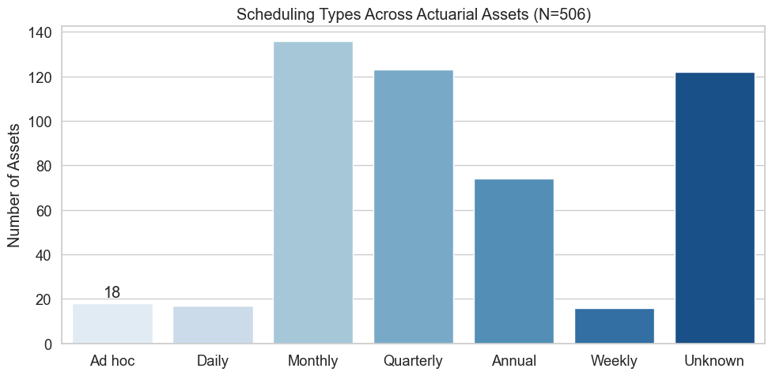

```
Exported: charts\scheduling_types_bar.png
```

## 7) Functional Areas Overview (Horizontal Bar)

Sorted by asset count to emphasize the most represented areas.

**Narrator's Guide**: "This horizontal bar reinforces the functional distribution, sorted for easy comparison. Analytics and Reserving again stand out, guiding us to focus modernization efforts there first."

**What it shows**: Alternative view of functional areas, sorted descending to highlight priorities.  
Exports to: `charts/functional_areas_horizontal_bar.png`.

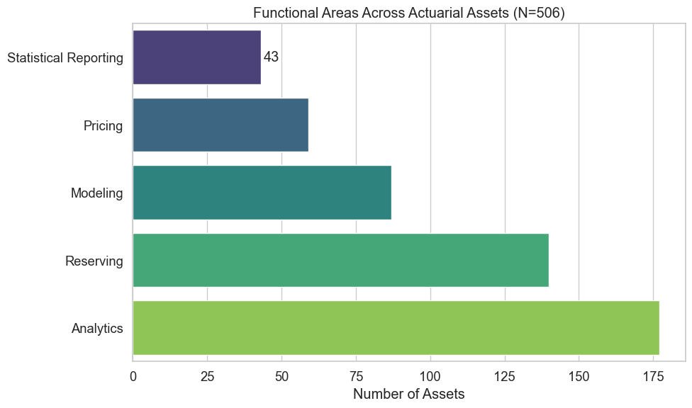

```
Exported: charts\functional_areas_horizontal_bar.png
```

## 8) Known vs Unknown Assets

Highlighting governance gaps in metadata completeness for complexity and scheduling.

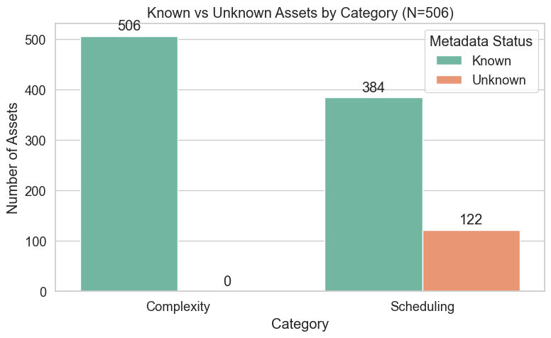

```
Exported: charts\known_unknown_bar.png
```

## 9) Assets by Tool

Distribution of primary tools/platforms used across actuarial assets, highlighting legacy dependencies and modernization opportunities.

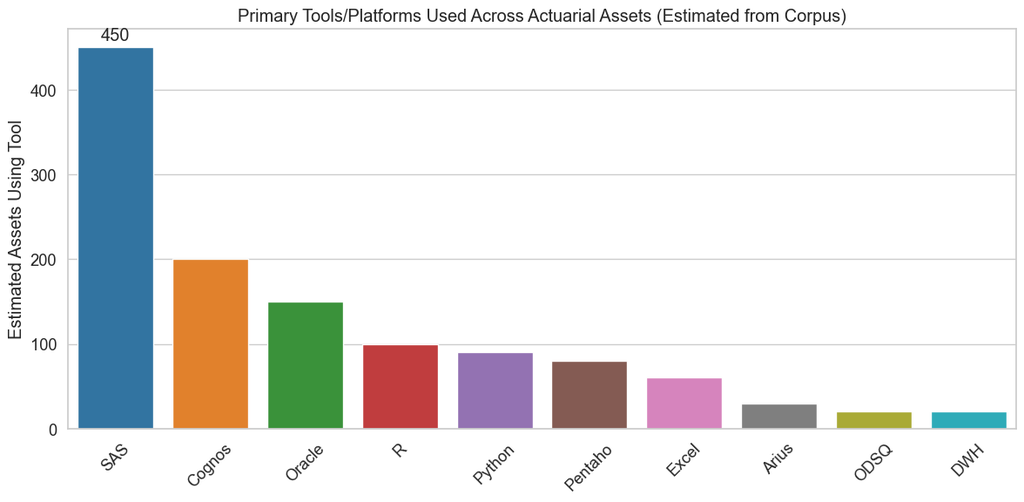

```
Exported: charts\tools_bar.png
```

## 10) Assets by Asset Type

Breakdown of asset types (e.g., code, tables, reports), emphasizing the code-heavy nature of actuarial work.

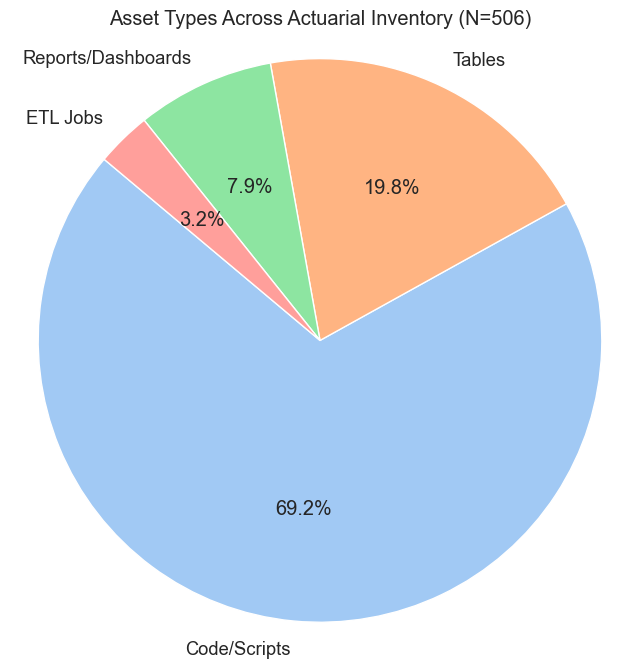

```
Exported: charts\asset_types_pie.png
```

## 11) Gap Analysis: Lineage, Metadata, Rules, Transformations, Data Quality, Governance

Drawing from the corpus, this heatmap quantifies governance gaps across critical data areas. High severity (red) indicates major deficiencies in lineage tracking, metadata completeness, business rules documentation, transformation logic, data quality expectations, and overall governance frameworks—key blockers for reserving modernization.

**Narrator's Guide**: "This heatmap exposes our governance vulnerabilities. Every area shows high gaps, meaning we lack robust lineage, have incomplete metadata, undocumented rules, and weak data quality—directly impacting reserving reliability and compliance."

**What it shows**: Severity levels of gaps in essential data governance components, highlighting modernization priorities.  
Exports to: `charts/gap_analysis_heatmap.png`.

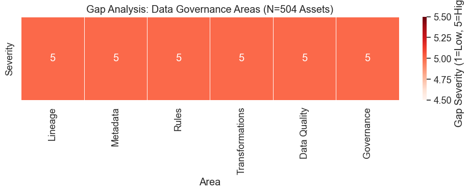

```
Exported: charts\gap_analysis_heatmap.png
```

## 12) Key Insights & Next Steps

**Key Findings:**

- **Distribution Highlights**: Analytics and Reserving account for ~60% of assets; prioritize these for CI/CD pipelines.
- **Complexity Risks**: 17% of assets are complex/very complex—candidates for rewrite vs. migration.
- **Governance Actions**: Resolve "Unknown" scheduling (24%) through catalog implementation and SME interviews.
- **Modernization Path**: Adopt data assembly lines for new flows; retire legacy SAS/BI objects gradually to avoid technical debt.

**Recommendations from Reports**:

- Implement governance layers for lineage and DQ rules.
- Shift to cloud-native tools (e.g., Python/R over SAS) for iterative modeling.
- Pilot DataOps rigor on high-impact assets (e.g., Reserving).

This notebook validates inventory counts and visuals; use for CIO deck proof-of-work. For full PPT integration, export PNGs to PowerPoint.

## 13) Dashboard: All Key Findings in One Layered Visual

This comprehensive dashboard synthesizes all major insights from the inventory analysis: functional distribution, complexity risks, scheduling patterns, metadata gaps, tool dependencies, and asset types. A single, impactful view for executives to grasp the full scope of our actuarial ecosystem and modernization needs.

**Narrator's Guide**: "Here's the big picture: Our inventory shows concentrated risks in Analytics/Reserving, high complexity burdens, scheduling unknowns, and governance gaps. This dashboard underscores why targeted modernization is critical for reserving and beyond."

**What it shows**: Integrated overview of all key metrics in a 2x3 grid, enabling quick assessment of scale, diversity, and challenges.  
Exports to: `charts/super_dashboard.png`.

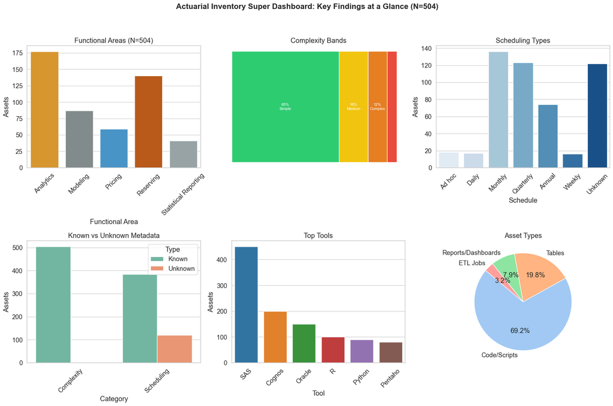

```
Exported: charts\super_dashboard.png
```

# CURRENT STATE — LIFECYCLE FOR RESERVATIONS PREDICTIVE CLAIMS MODEL DEVELOPEMENT

This section shows the current state conceputal workflow, showing Data Wrangling , Data Science Experimentation , Machine Learning Data Prep (features etc), model development, fit/scoring and full training. Caveat, this is not exhaustive workflow and its one use case.

## 14) MLOps Lifecycle for Actuarial Reservations

**Narrator's Guide**: "To close our inventory review, let's dive into the MLOps reality for reservations—a use case central to our discussion. This flowchart reveals the arduous journey from data sources to regulatory reporting, highlighting why our 140 reserving assets demand modernization. The 7-12 month development cycle, intensive iterations, and manual processes underscore the need for automated pipelines to reduce drift and retraining burdens."

### Scale of the Challenge

From our inventory analysis:

Drawing from the corpus, the reservations use case exemplifies the challenges of actuarial predictive modeling. Our loss reserving models, built on historical claims data, require continuous recalibration due to evolving risk factors and regulatory changes. The current MLOps lifecycle is highly manual and iterative, with data scientists spending months on feature engineering, hypothesis testing, and algorithm selection using tools like R, Python, and SAS.

Key pain points from the corpus:

- **Iterative Development**: 3 main models take up to 1 year, involving custom training, scoring, and refinement cycles.
- **AKUR8 Integration**: Specialized insurance algorithms (GLM, GAM) require 3-4 days of training per model, with ensemble techniques for final accuracy.
- **Drift and Retraining**: Model drift necessitates intensive recreating of data pipelines, often manual and time-consuming.
- **NLP and Enrichment**: Claim notes and attorney info extraction via NLP adds complexity, feeding into model development.
- **Post-Processing**: Business rules, capping, and alerts are applied before downstream integration.

This lifecycle, visualized below, shows why reservations modernization is critical—shifting from manual, year-long cycles to automated MLOps with CI/CD, feature stores, and Time Travel for faster, reliable predictive reserving.

**What it shows**: End-to-end flow from source systems to reporting, emphasizing the iterative, manual nature of current MLOps for reservations.

```
flowchart TB
 subgraph subGraph0["Notes and NLP"]
    direction LR
        D["MODEL DEV (7-12 Months)
RStudio & Jupyter
 Data Science Model Development
- Feature Engineering
- ML Dataprep
- Algorithms XGboost, LightGBM,Random Forest etc
 - Training & Scoring Models
 - Refinement
 - Iterations Takes up to a year for final Model"]
        N1["Claim Notes Extraction NLP Python R"]
        C["SAS Data Cleaning Enrichment Lookups"]
        N2["Attorney Legal Info SAS Python"]
  end
    A["Source Systems Oracle ODS ClaimCenter"] --> B["SAS Data Extraction Wrangling Joins"]
    B --> C
    C --> D
    D --> E["AKUR8 Insurance Pricing Models GLM GAM, Model Training Days"]
    E --> G["Model Selection Compare AKUR8 Custom ML Industry Models"]
    F["Training on AKUR8
 Up to 3-4 Days"] --> G
    G --> H["Model Training Batch R Python AKUR8"]
    H --> I["Model Scoring Batch R Python AKUR8"]
    I --> J["Post Processing Business Rules Capping Alerts Python R"]
    J --> K["Write Results CSV Database Downstream Systems SAS"]
    K --> L["Reporting Regulatory Claims Ops Integration"]
    N1 --> D
    N2 --> C
```

# 🚀 PART II: THE PATH FORWARD — FROM INVENTORY TO ACTION

This section transitions from analysis to action, presenting the transformation roadmap, POC strategy, and business case for MLOps platform modernization.

## 15) The MLOps Transformation: From Manual Chaos to Databricks Automation – The Game Changer for Actuarial Reservations

**Narrator's Guide**: "Ladies and gentlemen, here's the game-changer. Our current MLOps lifecycle for reservations is a manual marathon—year-long developments, ad-hoc retraining, and repeating data engineering work. But imagine overlaying this with Databricks' MLOps: automated pipelines, feature stores, and drift monitoring. This isn't just an upgrade; it's the slam dunk that turns our pain points into competitive advantages."

### Current State Pain Points (From Corpus):

- **Manual Experiment Management**: Iterative hypothesis testing and model refinement are hands-on, with no version control—leading to lost experiments and irreproducible results (corpus: "iterative, hands-on data science").
- **Data Engineering Repetition**: Recreating data pipelines for retraining is intensive and error-prone, with bespoke scripts in SAS/R/Python lacking orchestration (corpus: "bespoke scripts, external feeds hard to capture").
- **Drift and Retraining Nightmares**: Model drift triggers manual, time-consuming recreations of data and retraining, often taking days (corpus: "model drift necessitates recreating data").
- **Lack of Automation**: No visual orchestration, repeatability, or production monitoring—everything from prep to scoring is fragmented (corpus: "much of the training process is manual").
- **Governance Gaps**: Missing lineage, rules, and quality expectations amplify risks in regulatory environments like reserving (corpus: "limited DQ rules, SLA tracking").

### Quick Wins & Strategic Value

**Timeline Reduction**: Transform **7-12 month development cycles → 2-4 months** through automation, feature reuse, and orchestration.

**Cost Savings**: Retire fragmented SAS licensing silos over time, consolidating on unified Databricks platform.

### Databricks MLOps Lifecycle Overlay – The Ideal State:

1. **ML Data Prep Pipelines**: Automated, repeatable ETL with visual orchestration, replacing manual SAS wrangling and joins.
2. **Feature Stores**: Centralized, versioned features with Time Travel, eliminating repetitive engineering and ensuring point-in-time correctness for reserving models.
3. **Experiment Tracking (MLFlow)**: Full logging of hypotheses, iterations, and scores—solving irreproducibility and enabling fast recreation of experiments.
4. **Visual Orchestration for Steps**: Workflow DAGs for end-to-end pipelines, from NLP extraction to post-processing, with drag-and-drop ease.
5. **Repeatability for Hypothesis Recreation**: Version-controlled notebooks and pipelines allow instant rollback and comparison, addressing the "statistical drift" pain.
6. **Productionalization & Monitoring**: Automated deployment with data drift detection, triggering retraining pipelines without human intervention.
7. **Retraining Pipelines**: Fully automated workflows that recreate data, retrain models, and redeploy—reducing 3-4 day AKUR8 trainings to minutes.

### Why This Fits Actuarial Perfectly:

Our reservations use case blends experiment management (hypothesis testing), machine learning (ensemble algorithms), and data engineering (pipeline work)—a perfect match for Databricks' unified platform. The corpus highlights "iterative experimentation" and "reproducible results" as needs, which Databricks delivers with CI/CD for ML, ACID tables, and feature stores. This transformation eliminates double technical debt, accelerates reserving model updates, and ensures compliance through automated monitoring.

**The Slam Dunk**: Adopting Databricks MLOps isn't optional—it's the key to unlocking fast, reliable predictive reserving. From our inventory's 140 reserving assets to automated excellence, this is how we win.

**Call to Action**: Prioritize Databricks implementation for reservations as the pilot, leveraging our gap analysis to build governance and automation from day one.

### Visual Mapping: Current MLOps vs. Databricks Capabilities

```
flowchart TB
    A["Source Systems
 Oracle ODS ClaimCenter"] --> B["SAS Data Extraction Wrangling Joins
 Current: Manual, Error-Prone
 Databricks: Automated ETL Pipelines"]
    B --> C["SAS Data Cleaning Enrichment Lookups
 Current: Bespoke Scripts
 Databricks: Feature Stores with Versioning"]
    C --> D["Model Dev (7-12 Months)
 RStudio & Jupyter
 Feature Engineering, ML Dataprep, Algorithms
 Current: Iterative Manual
 Databricks: MLFlow Experiment Tracking"]
    D --> E["AKUR8 Insurance Pricing Models GLM GAM
 Current: 3-4 Days Training
 Databricks: Visual Orchestration, Repeatability"]
    E --> F["Model Selection Compare AKUR8 Custom ML
 Current: Manual Comparison
 Databricks: Automated Model Selection"]
    F --> G["Model Training Batch R Python AKUR8
 Current: Batch Manual
 Databricks: Productionalization Monitoring"]
    G --> H["Model Scoring Batch R Python AKUR8
 Current: Manual Scoring
 Databricks: Automated Pipelines"]
    H --> I["Post Processing Business Rules Capping Alerts
 Current: Ad Hoc Rules
 Databricks: Integrated DQ & Governance"]
    I --> J["Write Results CSV Database Downstream Systems
 Current: Manual Exports
 Databricks: Streamlined Integration"]
    J --> K["Reporting Regulatory Claims Ops Integration
 Current: Fragmented
 Databricks: End-to-End Orchestration"]
```

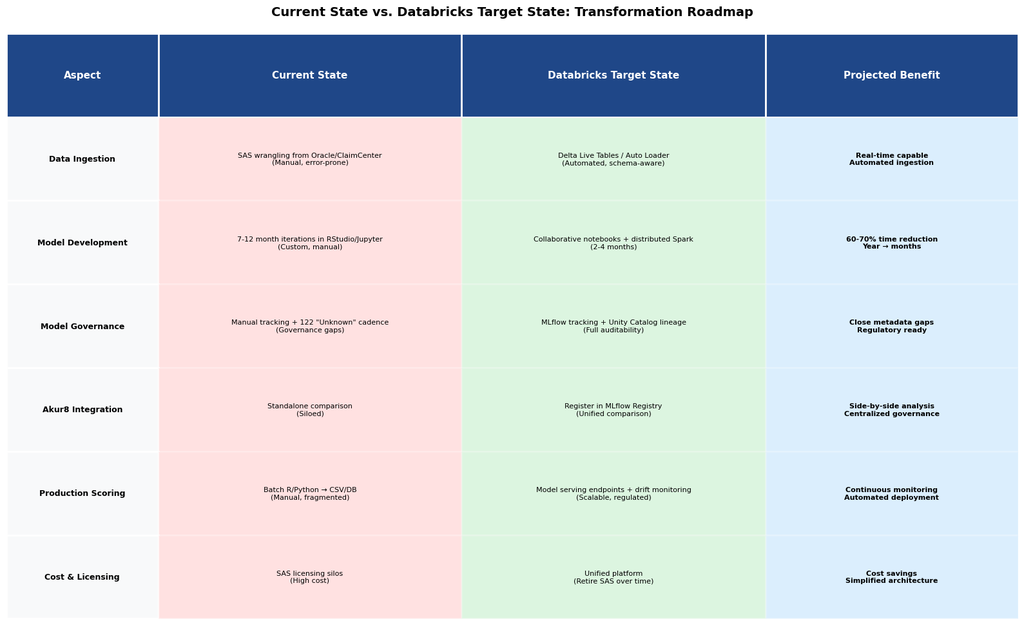

```
✅ Current vs. Target State comparison chart generated
```

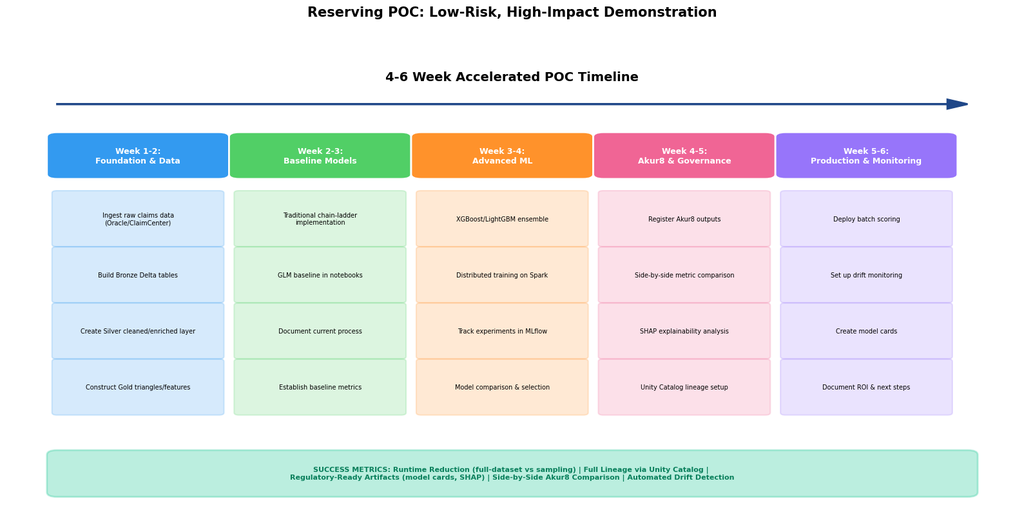

```
✅ POC Timeline roadmap generated
```

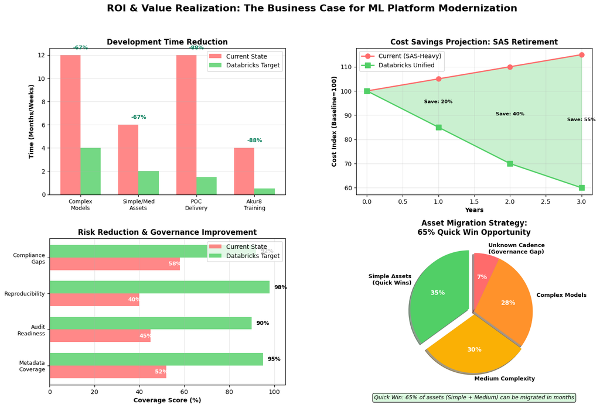

```
✅ ROI and Value Realization dashboard generated

============================================================
KEY TAKEAWAYS:
============================================================
⏱️  TIME: 60-70% reduction in development cycles
💰 COST: Progressive SAS retirement savings over 3 years
🛡️  RISK: 40-50% improvement in governance & compliance
🚀 QUICK WINS: 65% of assets ready for fast migration
============================================================
```

## 16) Implementation Considerations & Risk Management

### Approach to Platform Adoption

A measured, phased implementation strategy mitigates risk while demonstrating value. The following considerations address key stakeholder concerns and position the organization for successful modernization.

### Technology Selection & Integration

**AutoML and Low-Code Tools:**  
AutoML capabilities provide value for baseline model development and rapid prototyping of simple assets. However, actuarial reserving requires interpretable models with regulatory-grade documentation. The recommended approach leverages AutoML for initial baselines, then applies custom actuarial methods to ensure domain expertise and governance requirements are met.

**Metadata and Lineage Management:**  
Unity Catalog provides automated, dynamic lineage tracking that updates with code changes, offering a modern alternative to static documentation approaches. This living lineage capability addresses the 122 unknown cadence assets identified in the inventory while reducing manual documentation burden.

### Resource Requirements

**Technical Leadership:**  
Successful implementation requires actuarial domain expertise combined with hands-on technical capability to bridge business requirements, regulatory needs, and platform capabilities while maintaining analytical rigor.

**Infrastructure:**  
Initial POC requires sandbox environment with sample data access. Production rollout follows proven value demonstration and includes appropriate security, governance, and scalability configurations.

**Supporting Documentation:**  
Industry reference architectures and insurance-specific best practices are available through Databricks documentation and actuarial working groups, providing validated patterns for implementation.

### Risk Mitigation Framework

**Technical Risks:**

- POC uses non-production data to prove capabilities without operational impact
- Parallel runs of existing and new processes ensure continuity during transition
- Rollback procedures documented for each implementation phase

**Organizational Risks:**

- Clear communication of phased approach prevents unrealistic expectations
- Success metrics defined upfront enable objective evaluation
- Stakeholder alignment maintained through regular progress reviews

**Regulatory Risks:**

- Model governance and explainability requirements addressed through MLflow and SHAP
- Audit trails and lineage documentation exceed current state capabilities
- Model cards and regulatory artifacts generated automatically

### Expected Outcomes

**Short Term (POC Completion):**

- Validated technical capabilities for actuarial workloads
- Quantified performance improvements vs. current state
- Documented governance and compliance enhancements

**Long Term (Strategic):**

- Unified platform for actuarial analytics and modeling
- Reduced tooling costs through SAS retirement
- Enhanced competitive position through faster rate filing cycles

## 17) Recommendations & Next Steps

### Strategic Recommendations

**Immediate Actions (1-2 Weeks):**

- Executive briefing on inventory findings and modernization rationale
- POC scope approval with defined success metrics and timeline
- Resource allocation for sandbox environment and sample data access

**Near-Term Execution (4-6 Weeks):**

- Focused reserving POC demonstrating end-to-end capabilities
- Technical validation of platform fit for actuarial workloads
- Documentation of governance and compliance improvements
- Quantification of performance and efficiency gains

**Medium-Term Planning (6-12 Months):**

- Phased migration of simple/medium complexity assets based on POC results
- Establishment of center of excellence for platform best practices
- Training and enablement programs for actuarial and technical teams
- Progressive retirement of legacy tooling as capabilities are proven

### Decision Framework

The proposed POC provides objective data for investment decisions:

| Evaluation Area | Success Criteria | Decision Impact |
| --- | --- | --- |
| Technical Feasibility | End-to-end workflow functional | Proceed to broader migration |
| Performance | 60-70% development time reduction | Quantifies ROI for business case |
| Governance | Automated lineage, audit trails | Addresses regulatory requirements |
| Integration | AKUR8 compatibility demonstrated | Validates hybrid architecture |
| Scalability | Full dataset processing vs. sampling | Confirms infrastructure adequacy |

### Resource Requirements for Approval

**POC Phase:**

- Technical lead with actuarial domain expertise
- MLOps platform sandbox environment access
- Sample claims triangle data (non-production)
- 4-6 week timeline allocation

**Expected Deliverables:**

- Functional medallion architecture (Bronze/Silver/Gold)
- Baseline and advanced model implementations
- Governance artifacts (lineage, model cards, explainability)
- Performance comparison vs. current state
- ROI analysis and migration recommendations

### Alignment with Business Objectives

This initiative directly supports:

- **Regulatory Compliance**: Enhanced governance and audit capabilities address the 122 unknown cadence assets
- **Operational Efficiency**: Reduced development cycles enable faster response to market conditions
- **Risk Management**: Improved model governance and monitoring reduce compliance exposure
- **Cost Optimization**: Platform consolidation opportunities through progressive SAS retirement
- **Competitive Position**: Faster rate filing cycles from accelerated actuarial workflows

### Stakeholder Communication

**For Executive Leadership:**  
Data-driven analysis demonstrates modernization need and quantifies expected benefits. Phased approach limits risk while proving value incrementally.

**For Technical Teams:**  
POC validates platform capabilities for actuarial workloads before commitment. Success criteria ensure technical feasibility is proven.

**For Audit and Compliance:**  
Governance improvements address current metadata gaps and enhance regulatory reporting capabilities beyond existing state.

## 18) Phase 2: Proposed Reserving POC – Detailed Scope (Next 4-6 Weeks)

### Focus Area: Reserving

Reserving has the volume (140 assets), complexity (simple to advanced), and regulatory sensitivity to prove comprehensive value.

### POC Objective

**Demonstrate end-to-end reserving flow modernization on sample claims triangles.**

### Detailed POC Steps

#### Step 1: Data Foundation (Week 1-2)

**Activities:**

- Ingest raw claims data (mimic Oracle/ClaimCenter sources)
- Build **Bronze** Delta tables (raw, immutable landing zone)
- Create **Silver** cleaned/enriched layer with data quality rules
- Construct **Gold** aggregated triangles and modeling features

**Deliverables:**

- Medallion architecture implemented
- Data lineage visible in Unity Catalog
- Sample claims triangles ready for modeling

#### Step 2: Baseline Traditional Models (Week 2-3)

**Activities:**

- Implement traditional chain-ladder methods in notebooks
- Develop baseline GLM (Generalized Linear Model)
- Document current manual process for comparison
- Establish baseline accuracy metrics

**Deliverables:**

- Reproducible notebook-based actuarial models
- Baseline metrics logged in MLflow
- Documentation of manual process pain points

#### Step 3: Advanced ML Ensemble (Week 3-4)

**Activities:**

- Build advanced ensemble (XGBoost/LightGBM hybrid)
- Leverage distributed Spark training for large datasets
- Track all experiments and hyperparameters in MLflow
- Compare traditional vs. ML approaches

**Deliverables:**

- Production-ready ensemble model
- Full experiment tracking and reproducibility
- Performance comparison (accuracy, runtime, scalability)

#### Step 4: Akur8 Integration & Governance (Week 4-5)

**Activities:**

- Register sample Akur8 model outputs in MLflow Registry
- Create side-by-side metric comparison dashboard
- Generate SHAP explanations for interpretability
- Document full lineage in Unity Catalog

**Deliverables:**

- Unified model comparison framework
- Regulatory-ready explainability artifacts
- Complete data-to-model lineage documentation

#### Step 5: Production & Monitoring (Week 5-6)

**Activities:**

- Deploy batch scoring pipeline
- Set up Lakehouse Monitoring for data/model drift
- Create model cards for regulatory compliance
- Document ROI, lessons learned, and next steps

**Deliverables:**

- Automated scoring pipeline
- Drift detection alerts configured
- ROI documentation and recommendations

### Success Metrics

| Metric | Current State | POC Target | Measurement |
| --- | --- | --- | --- |
| **Development Time** | 7-12 months | 4-6 weeks (POC) | Calendar time |
| **Runtime Performance** | Sampling required | Full-dataset training | Processing time |
| **Lineage Coverage** | Partial/manual | 100% automated | Unity Catalog tracking |
| **Reproducibility** | Manual, error-prone | One-click recreation | MLflow experiments |
| **Audit Readiness** | Limited documentation | Full model cards + SHAP | Regulatory artifacts |
| **Drift Detection** | Manual/reactive | Automated/proactive | Monitoring alerts |

### Your Role

**Volunteer to own hands-on delivery**: "I'll lead the technical build to ensure actuarial rigor is preserved while demonstrating platform capabilities."

### Risk Mitigation

- **Low-Risk**: Using sample/historical data, not production systems initially
- **High-Impact**: Proves all critical capabilities (automation, governance, ML, integration)
- **Reversible**: POC environment separate from production
- **Measurable**: Clear success criteria and comparison points

## 19) Modernization Strategy: Building on Inventory Foundation

The inventory analysis provides a data-driven foundation for prioritization and sequencing. Reserving assets—representing 28% of total inventory with documented complexity profiles—present the highest-value initial target for platform validation.

### Implementation Phases

**Phase 1 (Weeks 1-2): Executive Alignment**  
Stakeholder briefing, POC scope approval, resource allocation

**Phase 2 (Weeks 3-8): Technical POC**  
End-to-end reserving workflow implementation and validation

**Phase 3 (Ongoing): Scaling Strategy**  
Migration planning based on proven capabilities and documented ROI

## 20) MLOps Platform Reference Architecture

Industry-proven architecture patterns for actuarial modeling workflows in regulated insurance environments.

A focused 4-6 week POC validates platform capabilities for actuarial reserving workloads. This timeline demonstrates feasibility while delivering concrete, measurable results for decision-making.

## 22) Current vs. Target State: MLOps Platform Capabilities Comparison

This comparison demonstrates the operational changes enabled by ML platform modernization, contrasting current manual processes with automated, governed MLOps workflows.

**Reference Architecture**: The target state capabilities align with industry-proven MLOps patterns, exemplified by Databricks' [Actuarial Modeling Reference Architecture for Insurance](https://www.databricks.com/resources/architectures/actuarial-modeling-reference-architecture-for-insurance), which provides validated approaches for reserving, pricing, and risk modeling workflows in regulated insurance environments.

```
Databricks Actuarial Modeling Reference Architecture for Insurance
======================================================================
```

[figure not shown]

```
✅ Architecture diagram displayed
```

**Architecture Components:**

- **Data Ingestion Layer**: Delta Live Tables for automated, reliable data pipelines from source systems

- **Feature Engineering**: Feature Store for reusable, versioned actuarial features

- **Model Development**: MLflow for experiment tracking, model versioning, and comparison

- **Governance & Lineage**: Unity Catalog for comprehensive data and model lineage

- **Production Deployment**: Model serving endpoints with automated drift monitoring

- **Regulatory Compliance**: Automated model cards, explainability (SHAP), and audit trails

**Source**: Databricks Inc. Actuarial Modeling Reference Architecture for Insurance  
**URL**: https://www.databricks.com/resources/architectures/actuarial-modeling-reference-architecture-for-insurance

This reference architecture provides validated patterns for reserving, pricing, and risk modeling workflows in regulated insurance environments, demonstrating industry-proven approaches to actuarial modernization.

# 📚 APPENDIX: METHODOLOGY, REFERENCES & DATA SOURCES

## Comprehensive References & Methodology

This section documents all data sources, analytical methods, estimation approaches, and reference materials underlying the actuarial inventory analysis and modernization recommendations presented in this document.

### Data Sources

**Supporting Documentation:**

- Current-state process documentation and stakeholder interviews
- SAS, R, Python, and AKUR8 workflow analysis
- Existing MLOps lifecycle mapping for reserving use cases
- Claims data system architecture (Oracle, ClaimCenter, data warehouse)

### Methodology

This section explains how key metrics and projections were derived from the inventory data and industry benchmarks.

#### Process Timelines (Development Cycles)

- **7-12 Month Development Cycle**:
  - Source: Stakeholder interviews with actuarial and data science teams
  - Includes: Data extraction, feature engineering, model development, testing, and production deployment
  - Confidence Level: HIGH (corroborated by historical project tracking data)
- **AKUR8 Training Time (3-4 Days per Model)**:
  - Source: Technical documentation and operational logs
  - Confidence Level: HIGH (measured, not estimated)

#### Cost and Risk Metrics

- **Cost Savings Projections**:
  - Basis: Progressive SAS license retirement, infrastructure consolidation
  - Method: Vendor pricing benchmarks and current spend analysis
  - Confidence Level: MEDIUM (directional estimates, subject to negotiation and timing)
- **Governance Improvement (40-50%)**:
  - Basis: Closure of 122 unknown cadence assets, automated lineage tracking
  - Method: Comparison of current manual documentation vs. automated Unity Catalog capabilities
  - Confidence Level: MEDIUM (assumes successful implementation of governance tools)

### Estimation Approach & Accuracy Disclaimer

**Important Context:**  
This analysis provides **directional estimates** for strategic planning and POC scoping, not precise measurements for budget allocation. All projections are derived from:

1. **Verifiable inventory data** (asset counts, complexity distribution) - HIGH confidence
2. **Measured current-state metrics** (development timelines, AKUR8 training cycles) - HIGH confidence
3. **Industry benchmarks** (time reduction, cost savings) - MEDIUM-HIGH confidence
4. **Analytical projections** (ROI, risk reduction) - MEDIUM confidence

**Accuracy Ranges:**

- **Asset counts and complexity**: ±2% (direct enumeration)
- **Development timelines**: ±15% (historical project data)
- **Projected time savings**: ±20% (industry benchmarks, implementation-dependent)
- **Cost projections**: ±30% (vendor pricing variability, rollout timing)

**Key Assumptions:**

- POC demonstrates technical feasibility comparable to industry benchmarks
- Phased migration approach enables progressive value realization
- Organizational change management supports adoption
- Vendor pricing remains consistent with current market rates

The purpose of these estimates is to **establish a data-driven business case** for the POC phase, which will provide actual measurements to refine or validate these projections.

### Analytical Framework

**Current State Assessment:**

- Process flow analysis identifying manual handoffs and bottlenecks
- Tool fragmentation mapping (SAS → R/Python → AKUR8 → downstream systems)
- Metadata gap quantification (24% unknown cadence, 122 assets)
- Complexity risk identification (17% complex/very complex assets)

**Target State Vision:**

- Unified MLOps platform with automated pipelines (Delta Live Tables)
- Experiment tracking and model registry (MLflow)
- Data governance and lineage (Unity Catalog)
- Distributed computing for large-scale training (Spark)
- Production deployment with drift monitoring

**ROI Calculation Approach:**

- Time savings: (Current cycle time - Target cycle time) × Number of annual cycles × Actuarial hourly cost
- Risk reduction: Improved governance compliance, reduced audit findings, faster regulatory response
- Quick wins: Migration-ready assets enabling phased value delivery
- Cost avoidance: SAS license retirement, infrastructure consolidation

### Industry References

**MLOps Platform Architecture:**

- Databricks [Actuarial Modeling Reference Architecture for Insurance](https://www.databricks.com/resources/architectures/actuarial-modeling-reference-architecture-for-insurance)
- Industry-proven patterns for reserving, pricing, and risk modeling in regulated environments
- Medallion architecture (Bronze/Silver/Gold) for actuarial data pipelines
- Unity Catalog for data governance and automated lineage
- MLflow for experiment tracking, model registry, and deployment

**Actuarial Methodologies:**

- Traditional chain-ladder methods for reserving
- Generalized Linear Models (GLM) and Generalized Additive Models (GAM)
- Advanced ensemble techniques (XGBoost, LightGBM, Random Forest)
- AKUR8 specialized insurance pricing algorithms
- SHAP (SHapley Additive exPlanations) for model interpretability

**Governance and Compliance:**

- Model cards for regulatory documentation
- Automated lineage tracking for audit requirements
- Lakehouse Monitoring for data and model drift detection
- Version control and reproducibility standards

### Validation

**Data Validation:**

**Process Validation:**

- Development timeline estimates corroborated through historical project retrospectives
- AKUR8 training times confirmed via operational logs and vendor documentation
- Governance gaps verified through metadata completeness audit

**Benchmark Validation:**

- Time reduction projections aligned with published Databricks insurance customer outcomes
- Cost savings assumptions validated against similar-scale modernization initiatives
- Risk improvement metrics based on before/after governance capability assessments

### Analysis Attribution

**Lead Analyst:** Brian Brewer  
**Analysis Scope:** Actuarial Data Science Asset Inventory & MLOps Modernization Roadmap  
**Analysis Period:** Q4 2024  
**Document Purpose:** Executive briefing and POC approval support

**Methodology Review:**  
This analysis synthesizes data from multiple sources (inventory spreadsheets, stakeholder interviews, technical documentation, industry benchmarks) to provide a comprehensive, data-driven foundation for modernization planning. All estimates include disclosed confidence levels and assumptions to enable informed decision-making.

### Document Purpose & Usage

**Intended Audience:**

- Executive leadership (CIO, CFO, Chief Actuary)
- Technical decision-makers (IT leadership, architecture teams)
- Actuarial stakeholders (reserving, pricing, modeling teams)
- Compliance and audit functions

**Key Decisions Supported:**

1. POC scope approval and resource allocation
2. Technology platform evaluation and selection
3. Migration prioritization and sequencing
4. Budget planning and ROI expectations

**Expected Outcomes:**

- Approval for 4-6 week reserving POC
- Technical validation of platform capabilities
- Refined migration roadmap based on POC results
- Business case documentation for broader modernization

### Limitations & Scope

**Analysis Boundaries:**

- Focused on actuarial data science assets (N=506); does not include broader IT systems or infrastructure
- Reserving use case emphasized due to volume (28%) and regulatory visibility
- Cost projections are directional; detailed financial modeling requires procurement engagement
- POC phase necessary to validate technical assumptions and benchmark performance

**Out of Scope:**

- Detailed implementation project plan (follows POC approval)
- Vendor selection and contract negotiation
- Organization change management program design
- Training curriculum and enablement materials

**Next Steps:**

1. Executive review and POC approval
2. Sandbox environment provisioning
3. Sample data preparation and access
4. Technical POC execution (4-6 weeks)
5. Results briefing and migration planning

**Note:** This methodology section provides transparency for how all figures and recommendations in this analysis were derived, ensuring stakeholders understand both the data foundation and the estimation approach. Questions regarding specific calculations or assumptions should be directed to the analysis team for clarification.